# distribution-functions

## Distribution Functions

Dont use this unless you have very specific use cases.

The most sensible option is to use Distr6 https://github.com/alan-turing-institute/distr6 for anything but the use case of testing various combined functions

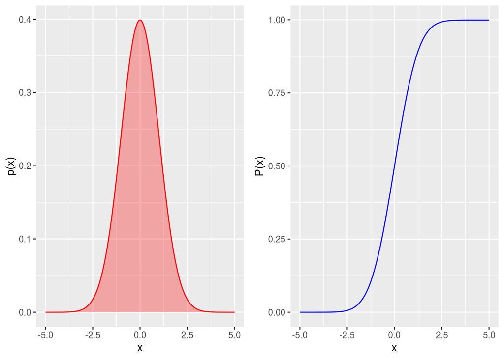

```r
n = NormalDistribution$new(mean=0,sd=1)
n$plot(-5,5)
```

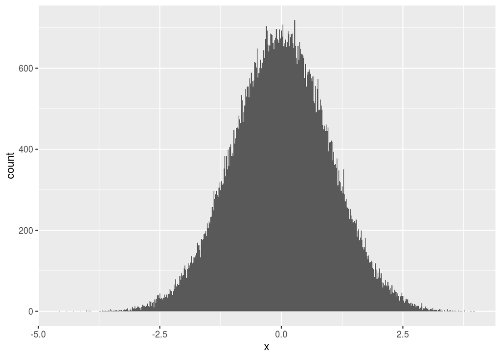

```r
ggplot(n$sample(100000),aes(x=x))+geom_histogram(bins = 500)
```

### Uniform density

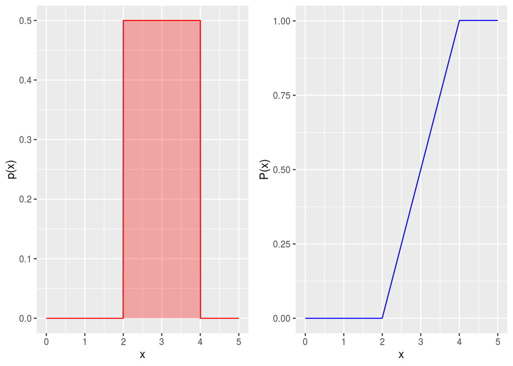

### Log Normal distribution

Log normal plots are specified using a mode and a measure of variance

```python
from sympy import *
import numpy as np
x, y, z, t = symbols('x y z t')
k, m, n = symbols('k m n', integer=True)
f, g, h = symbols('f g h', cls=Function)
print('<math>'+mathml(integrate(1/x, x))+'</math>')
```

$$\mathit{mode}={{e}^{\mu-{{\sigma}^{2}}}} \\
\mathit{var}={{e}^{2\cdot \mu-{{\sigma}^{2}}}}\cdot \left( {{e}^{{{\sigma}^{2}}}}-1\right)$$

This can be rearranged to the following:

$$\mathit{var}+{{e}^{\mu}}\cdot \mathit{mode}-{{e}^{2\cdot \mu}}=0$$

Which can be numerically solved for $\mu$ given the mode and variance, leaving the substitution for $\sigma$
$$\sigma=\sqrt{\mu-\mathrm{log}\left( \mathit{mode}\right) }$$

Which allows us to pecify a log normal distribution with meaningful shape parameters.

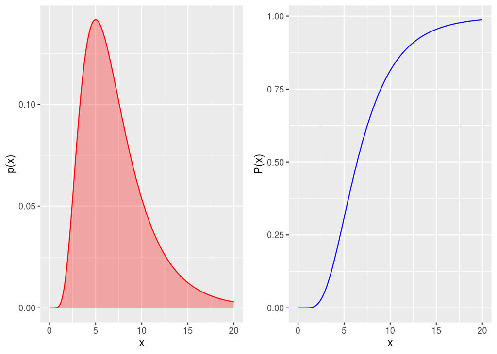

```r
n3 = LogNormalDistribution$new(mode=5,sd=3)
n3$plot(0,20)
```

## Combining distributions

Combining two distributions is also possible, and the default labelling can be overridden

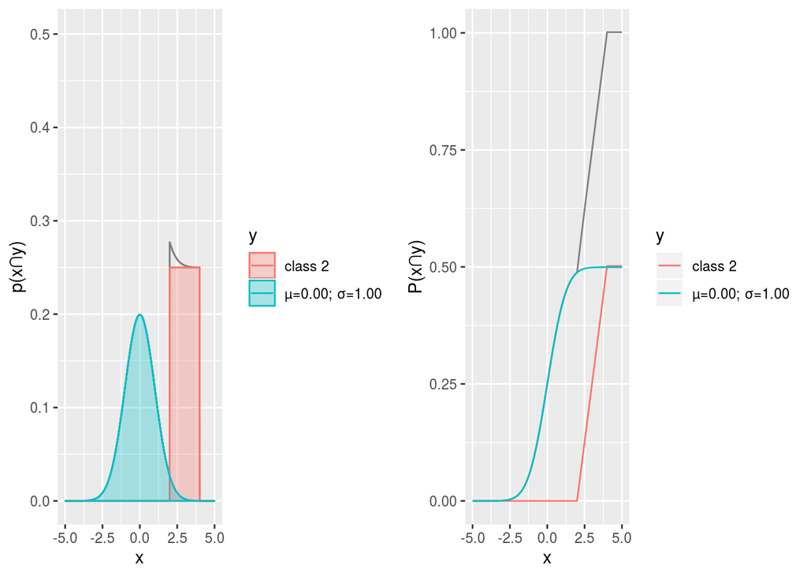

```r
cd = ConditionalDistribution$new()
cd$withDistribution(1,n)
cd$withDistribution(1,n2,"class 2")
cd$plot(xmin=-5,xmax=5)
```

And we can sample from this combined distribution which is returned as a dataframe containing the class in “y”

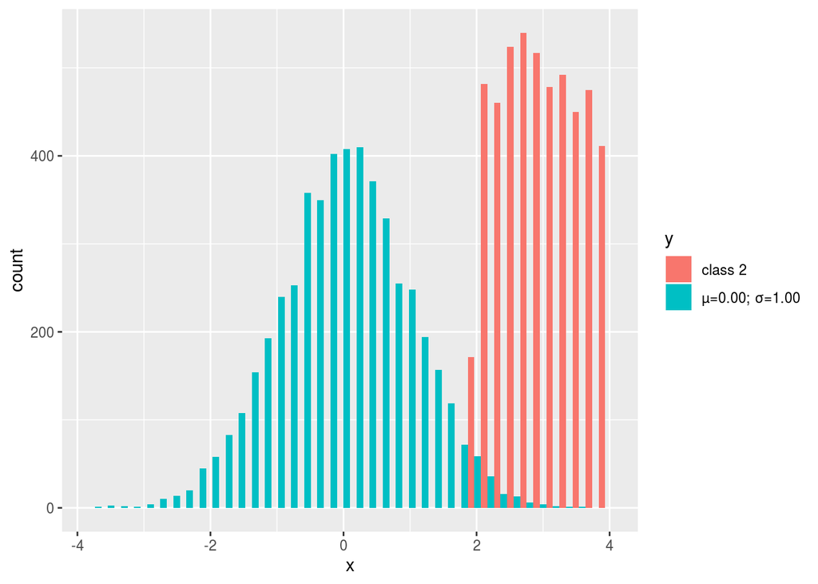

```r
ggplot(cd$sample(10000),aes(x=x,fill=y))+geom_histogram(position="dodge",bins=40)
```

A limited number of theoretical values are available for the combined distribution (well numerically calculated)

```r
paste0("Mean: ",cd$theoreticalMean())
```

```
## [1] "Mean: 1.50000008432913"
```

```r
paste0("Variance: ",cd$theoreticalVariance())
```

```
## [1] "Variance: 2.91668411265626"
```

```r
paste0("Mutual information between x and y: ",cd$theoreticalMI())
```

```
## [1] "Mutual information between x and y: 0.646359810780176"
```

For testing purposes it is also useful to be able to generate a sample from a random collection of distributions with approximately sensible defaults. This is possible with a random distribution selector which will randomly pick from the known distributions

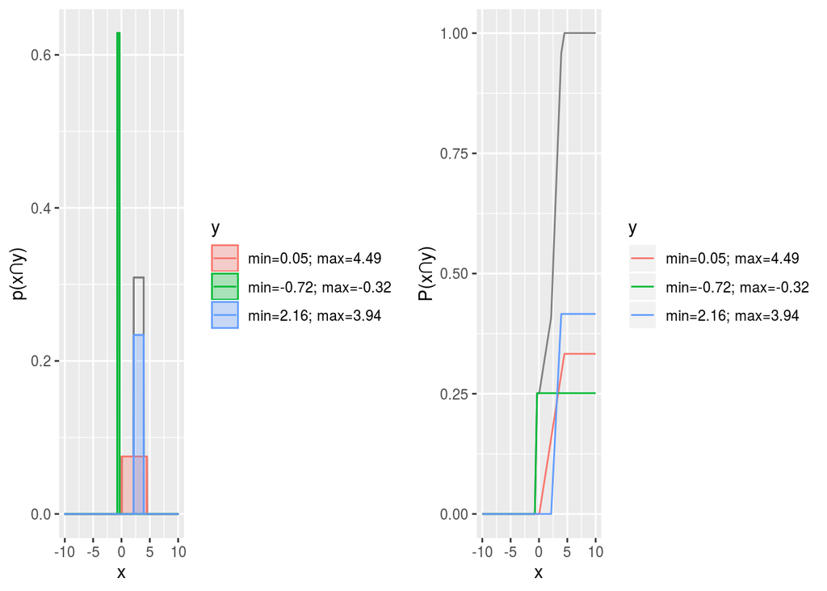

```r
cd3 = ConditionalDistribution$new()
cd3$withRandomDistributions(3)
cd3$plot(-10,10)
```